# Final Exam Part 2: Manchester Derby

Neil Shah

## Plots

My goal is to compare the overall ratings of the two different soccer teams located in Manchester to see which team is higher rated. First. I took the average overall of all the players on the each team. From this we can see that the average rating for Manchester United is roughly 77.242 compared to a mean overall of 76.727 for Manchester City. So, it appears that the players of Manchester United have a slightly higher average overall than Manchester City players.

```
## # A tibble: 1 x 1
##   mean_overalll
##           <dbl>
## 1          77.2
```

```
## # A tibble: 1 x 1
##   mean_overalll
##           <dbl>
## 1          76.7
```

However, this is not the best indicator of which team has more skillful players. So next, I decided to plot a boxplot for each team showing the overall player rating distribution of each team per position.

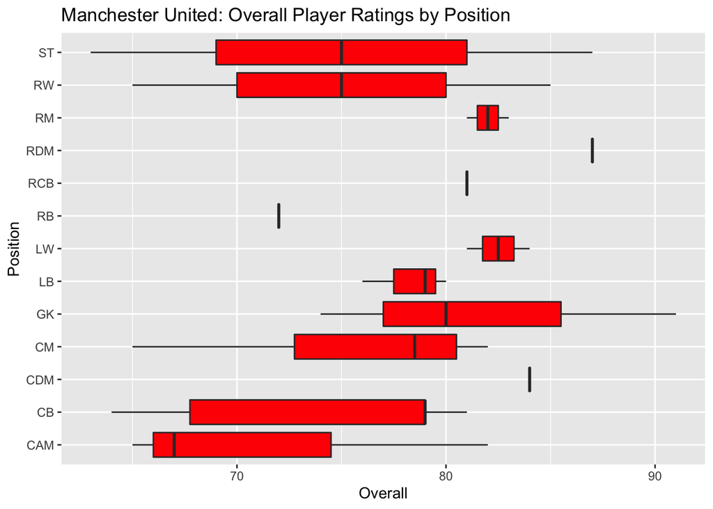

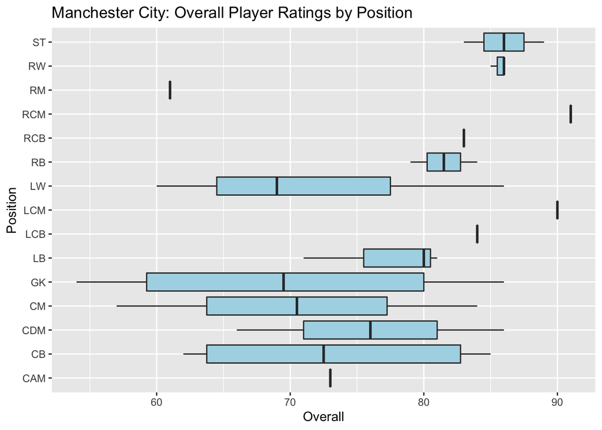

I also calculated the exact average overall of each position on both teams to accurately compare the two:

```
## # A tibble: 13 x 2
##    Position mean_overall
##    <chr>           <dbl>
##  1 CAM              71.3
##  2 CB               74.3
##  3 CDM              84
##  4 CM               76
##  5 GK               81.7
##  6 LB               78.3
##  7 LW               82.5
##  8 RB               72
##  9 RCB              81
## 10 RDM              87
## 11 RM               82
## 12 RW               75
## 13 ST               75
```

```
## # A tibble: 15 x 2
##    Position mean_overall
##    <chr>           <dbl>
##  1 CAM              73
##  2 CB               73.2
##  3 CDM              76
##  4 CM               70.5
##  5 GK               69.8
##  6 LB               77.3
##  7 LCB              84
##  8 LCM              90
##  9 LW               71.7
## 10 RB               81.5
## 11 RCB              83
## 12 RCM              91
## 13 RM               61
## 14 RW               85.7
## 15 ST               86
```

Based on the graphs and the tables above, we can observe that on average, some positions rank higher overall on one team compared to the other. For example, on Manchester United the average Striker overall is less than the average Manchester City overall. When analyzed for all positions we can note that Manchester United has a higher overall on average for Right Midfielder(RM), Left Wing(LW), Left Back(LB), Goal Keeper(GK), Center Midfielder(CM), Central Defensive Midfielder(CDM), and Center Back(CB).

When looking at what positions have higher overalls on average for Manchester City we see that it is higher for Center Attacking Midfielder(CAM), Right Back(RB), Right Center Back(RCB), Right Wing(RW), and Striker(ST).

Overall from this we can see that of the twelve shared positions between the two teams, Manchester United beats Manchester City on average overall ratings by position of a margin of 7-5.

## Aggregates

```r
Total_Off_United <- 82.50000 + 75.00000 + 75.00000
Total_Def_United <- 74.33333+78.33333   +72.00000   +81.00000+81.66667
Total_Mid_United <- 71.33333+84.00000+76.00000+ +82.00000
Total_Def_United
```

```
## [1] 387.3333
```

```r
Total_Mid_United
```

```
## [1] 313.3333
```

```r
Total_Off_United
```

```
## [1] 232.5
```

```r
Total_Off_City <- 71.66667 + 86.00000 + 85.66667
Total_Def_City <- 73.16667+77.33333+84.00000+81.50000+83.00000+69.75000
Total_Mid_City <- 73.00000+76.00000+70.50000+61.00000
Total_Def_City
```

```
## [1] 468.75
```

```r
Total_Mid_City
```

```
## [1] 280.5
```

```r
Total_Off_City
```

```
## [1] 243.3333
```

Using these totals, we can now see that Manchester United has a higher total Midfield category but Manchester City has a higher Offense and Defense total.

## Conclusion

After comparing the two teams, I would say that they are fairly evenly matched. Both teams are stronger in certain positions than the other but overall they still stay equal. When looking at the average player overall on Manchester United against City, we can see that Manchester United players are rated about 0.515 overall points higher than the average Manchester City player. This tells us that Manchester United is slightly more skilled than Manchester City.

Next, when looking at the breakdown of the player overalls by position, we can see that once again, Manchester United comes on top as the average overall is greater for Manchester United in 7 of the 12 shared positions between the two teams. Manchester City only has 5 positions that have a higher average overall compared to Manchester United.

Therefore, both teams are evenly matched and are only slightly better than eachother in certain categories.